# Homework 2 - Data analysis

Kyunghee Lee

**Release: 11/11**  
**Due: 11/25**

Change the author name to yours

```r
library(tidyverse)
# library(dplyr)
# library(tidyr)
houses <- read.csv("Boston_house_prices.csv")
```

# Question 1

- Q1-1. Spread the data out to multiple columns, with the shop type (Starbucks vs. Dunkin Donuts) being the column name (key) and the shops variable the value (Hint: tidyr).
- Q1-2. Delete observations that contain at least one missing value or invalud value (e.g. negative income).

```r
houses1 <- houses %>%
  spread(key =shop_type, value = shops)

houses2 <- houses1 %>%
  na.omit() %>%
  filter(median_income >= 0)
```

# Question 2

- Q2-1. To examine the relationship between house prices and Starbucks, make a scatter plot using ggplot2.
- Q2-2. Repeat Q2-1 using Dunkin Donuts instead of Starbucks.

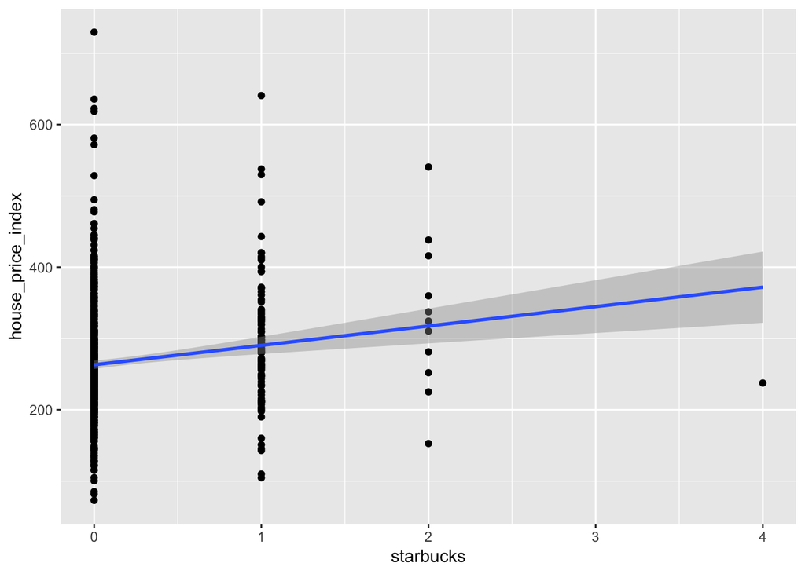

```r
ggplot(houses2, aes(x = starbucks, y = house_price_index)) +
  geom_point() +
  geom_smooth(method="lm")
```

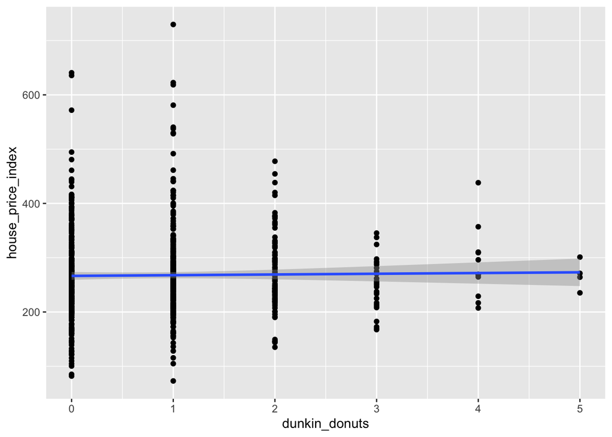

```r
ggplot(houses2, aes(x = dunkin_donuts, y = house_price_index)) +
  geom_point() +
  geom_smooth(method="lm")
```

# Question 3

- Q3. Make a linear regression model to predict house prices based on the number of Starbucks and Dunkin Donuts.

```r
lm(house_price_index ~ starbucks + dunkin_donuts, data = houses2) %>%
  summary()
```

```
##
## Call:
## lm(formula = house_price_index ~ starbucks + dunkin_donuts, data = houses2)
##
## Residuals:
##     Min      1Q  Median      3Q     Max
## -189.59  -44.64  -10.12   31.22  467.14
##
## Coefficients:
##               Estimate Std. Error t value Pr(>|t|)
## (Intercept)    264.486      3.683  71.803  < 2e-16 ***
## starbucks       28.314      6.817   4.154 3.63e-05 ***
## dunkin_donuts   -1.951      3.070  -0.636    0.525
## ---
## Signif. codes:  0 '***' 0.001 '**' 0.01 '*' 0.05 '.' 0.1 ' ' 1
##
## Residual standard error: 77.86 on 778 degrees of freedom
## Multiple R-squared:  0.02194,    Adjusted R-squared:  0.01943
## F-statistic: 8.726 on 2 and 778 DF,  p-value: 0.0001787
```

# Question 4

One might argue that neighborhoods where Starbucks are located are relatively rich. Does Starbucks have a predictive power for house prices, even after controlling for household incomes and population?

- Q4-1. Make new variables by taking log10 to median_income and population.
- Q4-2. Make a linear regression model to predict house prices based on the number of Starbucks and Dunkin Donuts, as well as (logarithm of) household incomes and population.

```r
houses2 <- houses2 %>%
  mutate(log_income = log10(median_income), log_pop = log10(population))

lm(house_price_index ~ starbucks + dunkin_donuts + log_income + log_pop, data = houses2) %>%
  summary()
```

```
##
## Call:
## lm(formula = house_price_index ~ starbucks + dunkin_donuts +
##     log_income + log_pop, data = houses2)
##
## Residuals:
##     Min      1Q  Median      3Q     Max
## -144.11  -40.81   -6.65   28.45  372.21
##
## Coefficients:
##                Estimate Std. Error t value Pr(>|t|)
## (Intercept)   -1387.788     87.884 -15.791  < 2e-16 ***
## starbucks        11.242      5.645   1.992   0.0468 *
## dunkin_donuts    -2.769      2.584  -1.071   0.2843
## log_income      252.095     14.407  17.498  < 2e-16 ***
## log_pop         114.608     16.843   6.805 2.03e-11 ***
## ---
## Signif. codes:  0 '***' 0.001 '**' 0.01 '*' 0.05 '.' 0.1 ' ' 1
##
## Residual standard error: 63.69 on 776 degrees of freedom
## Multiple R-squared:  0.3472, Adjusted R-squared:  0.3438
## F-statistic: 103.2 on 4 and 776 DF,  p-value: < 2.2e-16
```

# Question 5

The dynamics of house prices might vary across counties in Boston.

- Q5-1. Separate the plot resulting from Question 2 by county.
- Q5-2. Add county variable to the previous linear regression model (from Question 4).

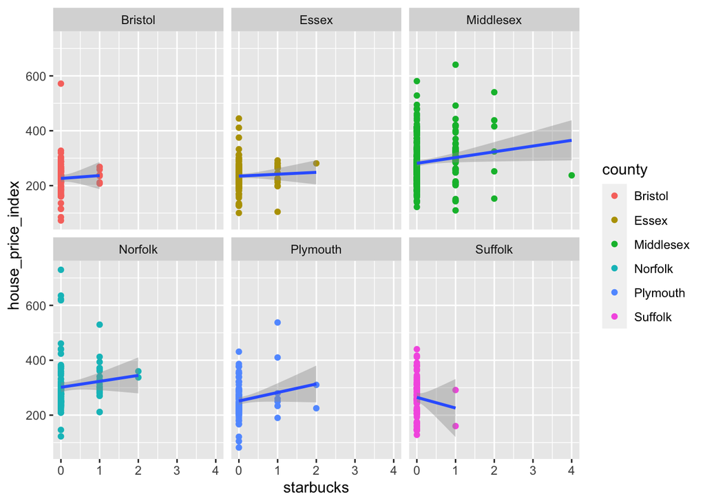

```r
ggplot(houses2, aes(x = starbucks, y = house_price_index)) +
  geom_point(aes(color=county)) +
  geom_smooth(method="lm") +
  facet_wrap(~county)
```

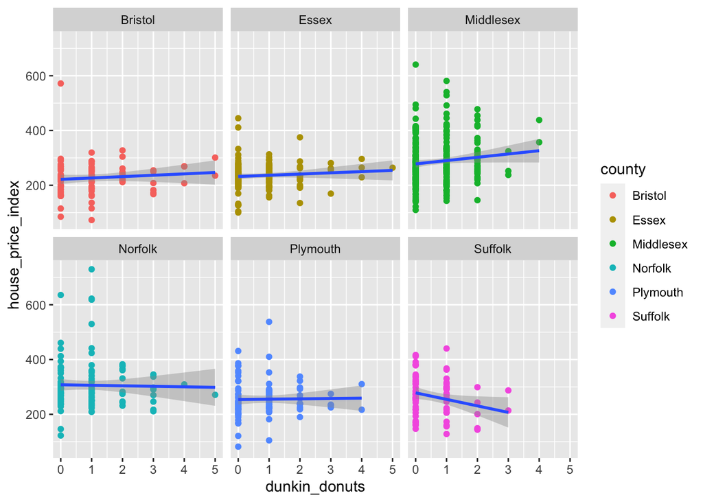

```r
ggplot(houses2, aes(x = dunkin_donuts, y = house_price_index)) +
  geom_point(aes(color=county)) +
  geom_smooth(method="lm") +
  facet_wrap(~county)
```

```r
lm(house_price_index ~ starbucks + dunkin_donuts + log_income + log_pop + county, data = houses2) %>%
  summary()
```

```
##
## Call:
## lm(formula = house_price_index ~ starbucks + dunkin_donuts +
##     log_income + log_pop + county, data = houses2)
##
## Residuals:
##     Min      1Q  Median      3Q     Max
## -156.82  -37.53   -5.74   28.29  353.27
##
## Coefficients:
##                  Estimate Std. Error t value Pr(>|t|)
## (Intercept)     -1330.035     88.588 -15.014  < 2e-16 ***
## starbucks           8.772      5.532   1.586  0.11319
## dunkin_donuts      -1.392      2.530  -0.550  0.58240
## log_income        237.483     14.582  16.287  < 2e-16 ***
## log_pop           113.028     16.410   6.888 1.18e-11 ***
## countyEssex        -4.710      8.395  -0.561  0.57492
## countyMiddlesex    24.458      7.877   3.105  0.00197 **
## countyNorfolk      41.743      8.871   4.706 3.00e-06 ***
## countyPlymouth      9.521      9.114   1.045  0.29651
## countySuffolk      42.069      9.774   4.304 1.89e-05 ***
## ---
## Signif. codes:  0 '***' 0.001 '**' 0.01 '*' 0.05 '.' 0.1 ' ' 1
##
## Residual standard error: 61.61 on 771 degrees of freedom
## Multiple R-squared:  0.3932, Adjusted R-squared:  0.3861
## F-statistic: 55.51 on 9 and 771 DF,  p-value: < 2.2e-16
```

# Question 6

Based on your analysis, do you agree or disagree that Starbucks is the bellwether of rise in house prices?